# Experimental Design I

Conor Fair

2025-10-3

# 1 Experimental Design

When designing experiments, one of the more consequential decisions is how treatments are assigned experimental units. We mentioned Gauss-Markov assumptions and that some assumptions deal with how the experiment is designed. The relevant assumption here is that experimental units are randomly assigned to treatments. When researchers don’t always have the tools or resources to meet this assumption, but thankfully there are methods to address this. When this assumption is met, the experiment is said to follow a completely randomized design (CRD).

## 1.1 Completely Randomized Design

### 1.1.1 Review the Experimental Design

Data published from (Mead et al. 1993) include trials of yield from four different melon varieties with six replicates or field plots. The allocation of the treatments (varieties) to the experimental units (plots) was completely at random - following a completely randomized design (CRD).

### 1.1.2 Importing the Data

```r
dat <- read_csv(here("data", "Completely_Randomized_Design.csv"))
str(dat)
```

```
## spc_tbl_ [24 × 4] (S3: spec_tbl_df/tbl_df/tbl/data.frame)
##  $ variety: chr [1:24] "v1" "v1" "v1" "v1" ...
##  $ yield  : num [1:24] 25.1 17.2 26.4 16.1 22.1 ...
##  $ row    : num [1:24] 4 1 4 1 1 2 4 3 4 2 ...
##  $ col    : num [1:24] 2 6 1 4 2 4 4 1 6 1 ...
##  - attr(*, "spec")=
##   .. cols(
##   ..   variety = col_character(),
##   ..   yield = col_double(),
##   ..   row = col_double(),
##   ..   col = col_double()
##   .. )
##  - attr(*, "problems")=<externalptr>
```

### 1.1.3 Data Description

The column variety needs to be encoded as a factor instead of the character variable R uses as a default. The mutate_at function changes the selected variable (variety) to the chosen variable type (as.factor).

```r
dat <- dat %>%
  mutate_at(vars(variety), as.factor)
str(dat)
```

```
## tibble [24 × 4] (S3: tbl_df/tbl/data.frame)
##  $ variety: Factor w/ 4 levels "v1","v2","v3",..: 1 1 1 1 1 1 2 2 2 2 ...
##  $ yield  : num [1:24] 25.1 17.2 26.4 16.1 22.1 ...
##  $ row    : num [1:24] 4 1 4 1 1 2 4 3 4 2 ...
##  $ col    : num [1:24] 2 6 1 4 2 4 4 1 6 1 ...
```

### 1.1.4 Experimental Design

When the data file has information about the experimental design that is relevant to the analysis, it can be helpful to produce a figure showing how treatment groups were assigned. We can produce a field layout of the trial using the desplot() function. The data object needs to have columns that identify the row and column of each plot in the trial. The form argument fills the color of each experimental unit by variety in this instance. The text argument shows the variety names in each plot. The remaining arguments are formatting including the main title and the key is turned off in this instance.

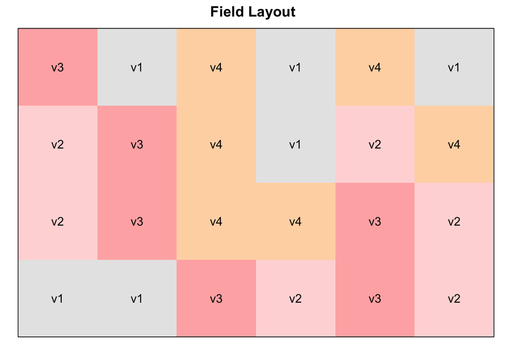

```r
desplot(data = dat, flip = TRUE,
        form = variety ~ col + row,
        text = variety, cex = 1, shorten = "no",
        main = "Field Layout", show.key = F)
```

It is also a good idea to look at the arithmetic means and standard deviations for each variety.

```r
dat %>%
  group_by(variety) %>%
  summarize(mean = mean(yield),
            std.dev = sd(yield))
```

| variety | mean | std.dev |
| --- | --- | --- |
| v1 | 20.49000 | 4.694422 |
| v2 | 37.40333 | 3.950497 |
| v3 | 19.49167 | 5.560052 |
| v4 | 29.89667 | 2.229894 |

A simple plot of the raw data also helps to visualize the distribution of the yield for each variety. The point geometry produces a scatter plot. The ylim argument forced the y-axis to start at 0. The theme_classic argument produces a clearer plot format.

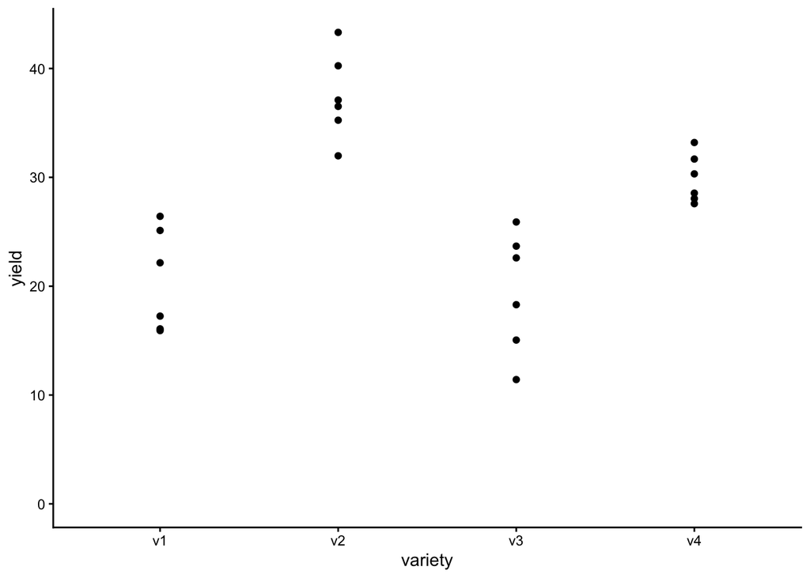

```r
ggplot(data = dat,
       aes(y = yield, x = variety)) +
  geom_point() +
  ylim(0, NA) +
  theme_classic()
```

### 1.1.5 Fitting ANOVA Models with R

We fit a linear model with yield as the response variable and variety as the fixed effect. The goal is to determine if there is a difference in yield between varieties and where those differences are. This should be familiar from the previous lesson as a One-Way ANOVA.

```r
mod <- lm(yield ~ variety, data = dat)
summary(mod)
```

```
##
## Call:
## lm(formula = yield ~ variety, data = dat)
##
## Residuals:
##     Min      1Q  Median      3Q     Max
## -8.0717 -2.5475 -0.5933  3.1571  6.4083
##
## Coefficients:
##             Estimate Std. Error t value Pr(>|t|)
## (Intercept)  20.4900     1.7504  11.706 2.10e-10 ***
## varietyv2    16.9133     2.4754   6.833 1.22e-06 ***
## varietyv3    -0.9983     2.4754  -0.403  0.69100
## varietyv4     9.4067     2.4754   3.800  0.00112 **
## ---
## Signif. codes:  0 '***' 0.001 '**' 0.01 '*' 0.05 '.' 0.1 ' ' 1
##
## Residual standard error: 4.288 on 20 degrees of freedom
## Multiple R-squared:  0.7784, Adjusted R-squared:  0.7452
## F-statistic: 23.42 on 3 and 20 DF,  p-value: 9.439e-07
```

The Anova function produces the table of F-Statistics to determine if there significant differences among the different levels of the varieties tested. Given there is only one term in the model type 1 and 2 would produce the same results and type 3 is inappropriate without an interaction term (produces the same values regardless).

```r
mod %>% car::Anova(type = 2)
```

|  | Sum Sq | Df | F value | Pr(>F) |
| --- | --- | --- | --- | --- |
| variety | 1291.4771 | 3 | 23.4184 | 9e-07 |
| Residuals | 367.6531 | 20 | NA | NA |

```r
epsilon <- residuals(mod)
```

Here we report the numerator and denominator degrees of freedom, the F value, and the p value: F(3,20)=23.418, p value < 0.0001). Remember that this test only tells us that there is a significant difference among the levels of the categorical variable. It doesn’t say which levels are significantly different.

### 1.1.6 Assumptions

We show the qqnorm and residuals vs fitted plots and the formal statistical tests.

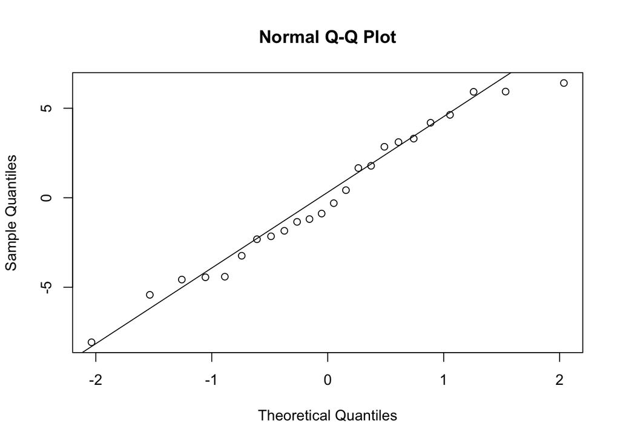

```r
qqnorm(epsilon)
qqline(epsilon)
```

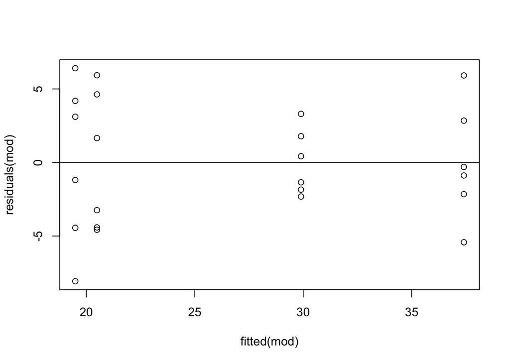

```r
plot(residuals(mod) ~ fitted(mod))
abline(h = 0)
```

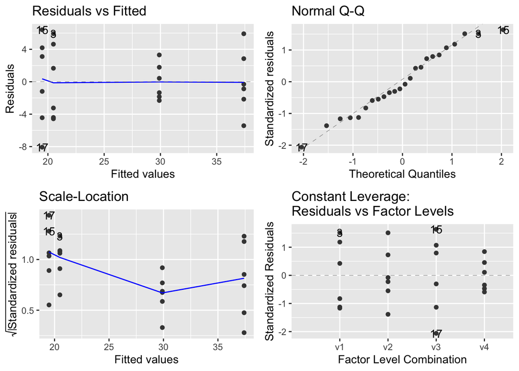

```r
autoplot(mod)
```

```r
shapiro.test(epsilon)
```

```
##
##  Shapiro-Wilk normality test
##
## data:  epsilon
## W = 0.96805, p-value = 0.619
```

```r
car::leveneTest(yield ~ variety, dat, center = mean)
```

|  | Df | F value | Pr(>F) |
| --- | --- | --- | --- |
| group | 3 | 2.509142 | 0.0880498 |
|  | 20 | NA | NA |

The results of the figures and tests indicate that the model assumptions are met.

### 1.1.7 Mean Comparisons

Following a significant F-test, we use the emmeans function to produce the estimated marginal means and the multiple comparisons tests using the cld function. Tukey is a commonly used method - the default setting so no code is required.

```r
mean_comparisons_tukey <- mod %>%
  emmeans(specs = "variety") %>%
  cld(Letters = letters)
mean_comparisons_tukey
```

|  | variety | emmean | SE | df | lower.CL | upper.CL | .group |
| --- | --- | --- | --- | --- | --- | --- | --- |
| 3 | v3 | 19.49167 | 1.750365 | 20 | 15.84047 | 23.14286 | a |
| 1 | v1 | 20.49000 | 1.750365 | 20 | 16.83880 | 24.14120 | a |
| 4 | v4 | 29.89667 | 1.750365 | 20 | 26.24547 | 33.54786 | b |
| 2 | v2 | 37.40333 | 1.750365 | 20 | 33.75214 | 41.05453 | c |

### 1.1.8 Data Visualization

Create a plot that displays both the raw data and results from the multiple comparisons tests of the adjusted means from the linear model.

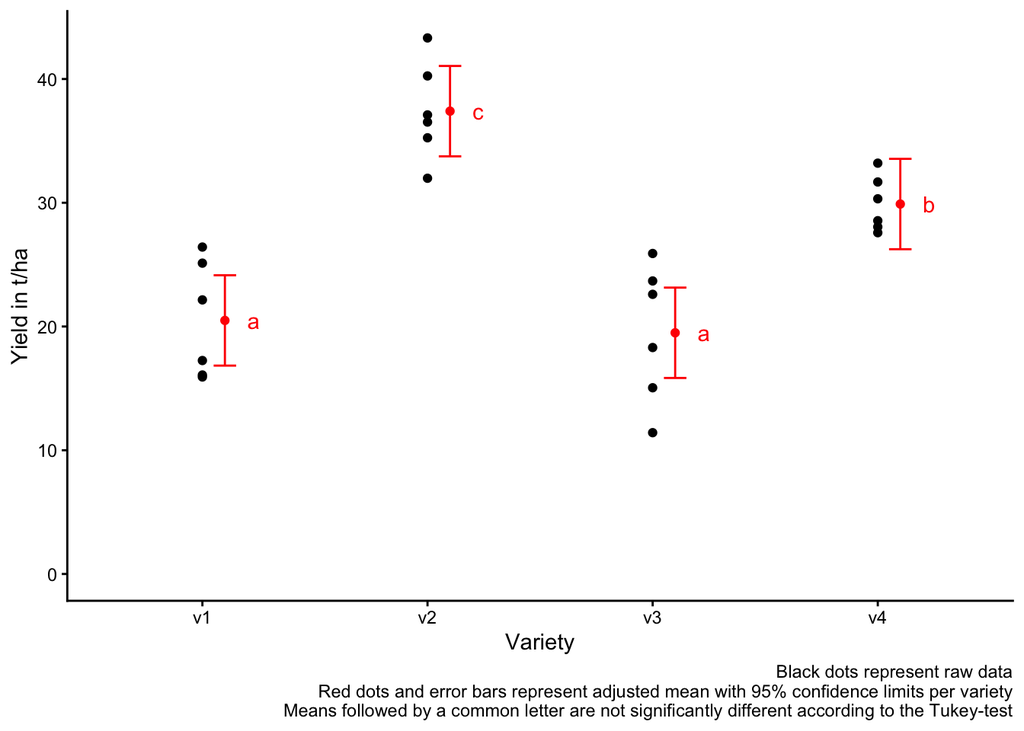

```r
CRD_Plot_tukey <- ggplot() +
  # black dots representing the raw data
  geom_point(data = dat, aes(y = yield, x = variety)) +
  # red dots representing the adjusted means
  geom_point(data = mean_comparisons_tukey, aes(y = emmean, x = variety), color = "red", position = position_nudge(x = 0.1)) +
  # red error bars representing the confidence limits of the adjusted means
  geom_errorbar(data = mean_comparisons_tukey, aes(ymin = lower.CL, ymax = upper.CL, x = variety), color = "red", width = 0.1,  position = position_nudge(x = 0.1)) +
  # red letters
  geom_text(data = mean_comparisons_tukey, aes(y = emmean, x = variety, label = str_trim(.group)), color = "red", position = position_nudge(x = 0.2), hjust = 0) +
  ylim(0, NA) + # force y-axis to start at 0
  ylab("Yield in t/ha") + # label y-axis
  xlab("Variety") +      # label x-axis
  labs(caption = "Black dots represent raw data
       Red dots and error bars represent adjusted mean with 95% confidence limits per variety
       Means followed by a common letter are not significantly different according to the Tukey-test") +
  theme_classic() # clearer plot format
CRD_Plot_tukey
```

We have been adding a couple of helpful details for figures using ggplot. We can offset the position of the raw data and the means with confidence intervals using the position_nudge argument. When showing the text of the cld results, the str_trim argument removes the blank space around the letters. The ylim function allows us to force the y-axis to start at values we set. In the labs function we can create a caption that defaults to the bottom of the figure.

## 1.2 Randomized Compelte Block Design

When dealing with an experiment in the field there is often unexplained variation in the physical space that may impact the measurements of the dependent variable. This unexplained variation is usually not desirable but a nuisance that can obscure the relationship of interest. Thankfully there is an approach where we can easily account for this unexplained variation to better isolate the relationship of interest. Portions of the physical space (e.g., field) can be sectioned into blocks along a theorized gradient (e.g., elevation, disturbance, locations, etc.) of this unexplained variation. The measurements collected from the different blocks can be recognized in the model so that this portion of unexplained variation is measured and the relationship of interest can be more accurately estimated.

### 1.2.1 Review the Experimental Design

Data published from (Gomez & Gomez 1984) include trials of yield from four different rice genotypes and six nitrogen levels (24 treatment level combinations) with three complete blocks (rep). The allocation of the treatments (varieties) to the experimental units (plots) follow a Randomized Complete Block Design (RCBD).

### 1.2.2 Importing the Data

See the “tidy” format

```r
dat <- read_csv(here("data", "Randomized_Complete_Block_Design.csv"))
```

### 1.2.3 Data Description

The variables rep, N, and G needs to be encoded as a factor instead of the character variable R uses as a default. The mutate_at function changes the selected variable (rep, N, or G) to the chosen variable type (as.factor).

```r
dat <- dat %>%
  mutate_at(vars(rep, N, G), as.factor)
str(dat)
```

```
## tibble [72 × 6] (S3: tbl_df/tbl/data.frame)
##  $ row  : num [1:72] 2 3 2 1 2 3 4 4 3 1 ...
##  $ col  : num [1:72] 6 4 3 1 1 1 5 1 2 2 ...
##  $ rep  : Factor w/ 3 levels "rep1","rep2",..: 1 1 1 1 1 1 1 1 1 1 ...
##  $ N    : Factor w/ 6 levels "N1","N2","N3",..: 1 2 4 6 3 5 1 2 4 6 ...
##  $ G    : Factor w/ 4 levels "A","B","C","D": 1 1 1 1 1 1 2 2 2 2 ...
##  $ yield: num [1:72] 4520 5598 6192 8542 5806 ...
```

### 1.2.4 Exploring the Data

We now produce a field layout of the trial using the desplot() function just like in the CRD above. Notice how the nitrogen and genotype treatments are randomly assigned within each rep (block). Each level of nitrogen and genotype are represented within each block (complete).

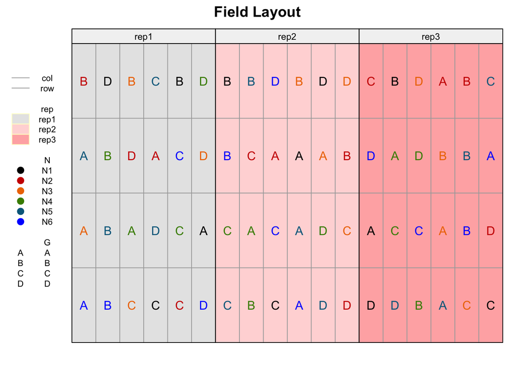

```r
desplot(data = dat,
        form = rep ~ col + row | rep, # fill color per rep, headers per rep
        text = G, cex = 1, shorten = "no", # show genotype names per plot
        col = N, # color of genotype names for each N-level
        out1 = col, out1.gpar = list(col = "darkgrey"), # lines between columns
        out2 = row,out2.gpar = list(col = "darkgrey"), # lines between rows
                main = "Field Layout", show.key = T, key.cex = 0.7) # formatting
```

We can also look at the arithmetic means and standard deviations for each genotype and nitrogen levels separately, but also their combinations. You can also arrange the tibble based on decreasing mean values

```r
dat %>%
  group_by(G) %>%
  dplyr::summarize(mean = mean(yield),
            std.dev = sd(yield)) %>%
  arrange(desc(mean))
```

| G | mean | std.dev |
| --- | --- | --- |
| A | 6553.556 | 1475.277 |
| B | 6155.500 | 1077.678 |
| C | 5563.444 | 1269.312 |
| D | 3642.111 | 1433.630 |

```r
dat %>%
  group_by(N) %>%
  dplyr::summarize(mean = mean(yield),
            std.dev = sd(yield)) %>%
  arrange(desc(mean))
```

| N | mean | std.dev |
| --- | --- | --- |
| N3 | 5866.250 | 832.4376 |
| N4 | 5864.417 | 1433.5578 |
| N5 | 5812.000 | 2349.4996 |
| N6 | 5796.750 | 2659.6879 |
| N2 | 5478.167 | 657.3105 |
| N1 | 4054.333 | 671.5853 |

```r
dat %>%
  group_by(N, G) %>%
  dplyr::summarize(mean = mean(yield),
            std.dev = sd(yield)) %>%
  arrange(desc(mean)) %>%
  print(n = Inf) #show more than default 10 rows
```

[output not shown]

```
## # A tibble: 24 × 4
## # Groups:   N [6]
##    N     G      mean std.dev
##    <fct> <fct> <dbl>   <dbl>
##  1 N6    A     8701.   270.
##  2 N5    A     7563.    86.9
##  3 N5    B     6951.   808.
##  4 N4    B     6895    166.
##  5 N4    A     6733.   490.
##  6 N5    C     6687.   496.
##  7 N6    B     6540.   936.
##  8 N3    A     6400    523.
##  9 N3    B     6259    499.
## 10 N6    C     6065.  1097.
## 11 N4    C     6014    515.
## 12 N3    C     5994    101.
## 13 N2    B     5982    684.
## 14 N2    A     5672    458.
## 15 N2    C     5443.   589.
## 16 N2    D     4816    506.
## 17 N3    D     4812    963.
## 18 N1    D     4481.   463.
## 19 N1    B     4306    646.
## 20 N1    A     4253.   248.
## 21 N4    D     3816   1311.
## 22 N1    C     3177.   453.
## 23 N5    D     2047.   703.
## 24 N6    D     1881.   407.
```

A simple plot of the raw data also helps to visualize the distribution of the yield for each genotype nitrogen treatment combination. Remember the point geometry produces a scatter plot. The ylim argument forced the y-axis to start at 0. The theme_classic argument produces a clearer plot format. The facet_wrap function produces a figure for each level of the genotype.

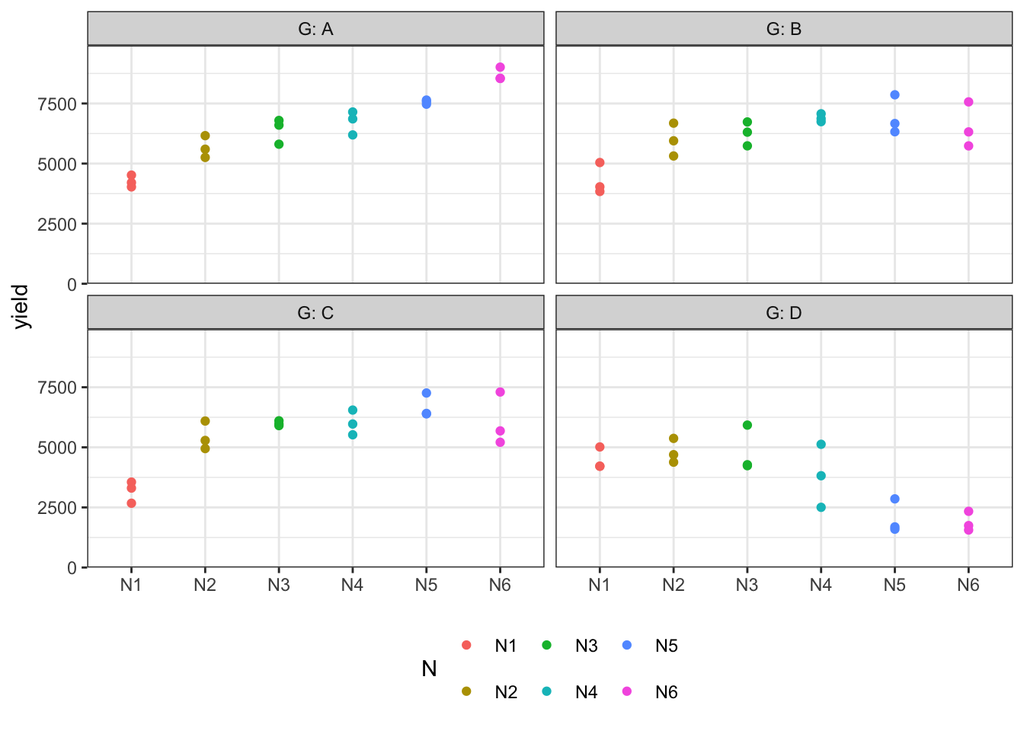

```r
ggplot(data = dat,
       aes(y = yield, x = N, color = N)) + # different colors for the level of nitrogen
  facet_wrap(~ G, labeller = label_both) + # facet per G level
  geom_point() +
  scale_y_continuous(limits = c(0, NA), # make y=axis start at 0
                     expand = expansion(mult = c(0, 0.1)) # no space below 0 on the y-axis
                     ) +
  scale_x_discrete(name = NULL) + # x-axis with no name label
  theme_bw() + # alternative plot theme with more grid lines - personal preference for theme_classic
  theme(legend.position = "bottom") # legend on bottom
```

### 1.2.5 Fitting ANOVA Models with R

We fit a linear model with yield as the response variable and genotype, nitrogen level, and their interaction as the fixed effects. Additionally there needs to be a term to represent the blocks from the experimental design. The decision to model block as a fixed or random effect should be considered carefully. We will discuss this decision further in the Mixed Effects Models lecture, but for now we are going to present the fixed effects results only.

```r
mod_fe <- lm(yield ~ N * G + rep, data = dat)
summary(mod_fe)
```

```
##
## Call:
## lm(formula = yield ~ N * G + rep, data = dat)
##
## Residuals:
##     Min      1Q  Median      3Q     Max
## -1203.1  -383.7   -92.1   396.4  1138.5
##
## Coefficients:
##             Estimate Std. Error t value Pr(>|t|)
## (Intercept)  4143.72     377.25  10.984 1.89e-14 ***
## NN2          1419.33     512.59   2.769 0.008080 **
## NN3          2147.33     512.59   4.189 0.000125 ***
## NN4          2480.00     512.59   4.838 1.51e-05 ***
## NN5          3310.67     512.59   6.459 5.93e-08 ***
## NN6          4448.00     512.59   8.678 3.03e-11 ***
## GB             53.33     512.59   0.104 0.917584
## GC          -1075.33     512.59  -2.098 0.041440 *
## GD            228.67     512.59   0.446 0.657616
## reprep2       280.46     181.23   1.548 0.128583
## reprep3        46.37     181.23   0.256 0.799173
## NN2:GB        256.67     724.91   0.354 0.724906
## NN3:GB       -194.33     724.91  -0.268 0.789836
## NN4:GB        109.00     724.91   0.150 0.881135
## NN5:GB       -666.00     724.91  -0.919 0.363025
## NN6:GB      -2213.67     724.91  -3.054 0.003751 **
## NN2:GC        846.00     724.91   1.167 0.249206
## NN3:GC        669.33     724.91   0.923 0.360650
## NN4:GC        356.67     724.91   0.492 0.625047
## NN5:GC        199.33     724.91   0.275 0.784565
## NN6:GC      -1560.00     724.91  -2.152 0.036680 *
## NN2:GD      -1084.67     724.91  -1.496 0.141410
## NN3:GD      -1816.67     724.91  -2.506 0.015808 *
## NN4:GD      -3145.33     724.91  -4.339 7.76e-05 ***
## NN5:GD      -5745.33     724.91  -7.926 3.81e-10 ***
## NN6:GD      -7048.67     724.91  -9.724 9.85e-13 ***
## ---
## Signif. codes:  0 '***' 0.001 '**' 0.01 '*' 0.05 '.' 0.1 ' ' 1
##
## Residual standard error: 627.8 on 46 degrees of freedom
## Multiple R-squared:  0.9132, Adjusted R-squared:  0.8661
## F-statistic: 19.37 on 25 and 46 DF,  p-value: < 2.2e-16
```

```r
car::Anova(mod_fe, type = 3)
```

|  | Sum Sq | Df | F value | Pr(>F) |
| --- | --- | --- | --- | --- |
| (Intercept) | 47548894 | 1 | 120.646309 | 0.0000000 |
| N | 35269882 | 5 | 17.898128 | 0.0000000 |
| G | 3162391 | 3 | 2.674656 | 0.0582103 |
| rep | 1084820 | 2 | 1.376263 | 0.2627220 |
| N:G | 69378044 | 15 | 11.735576 | 0.0000000 |
| Residuals | 18129432 | 46 | NA | NA |

```r
epsilon <- residuals(mod_fe) #used to test model assumptions
```

We see a significant interaction effect between nitrogen and genotype so we won’t be testing the main effects independently. Also the rep (block) effect isn’t significant.

### 1.2.6 Assumptions

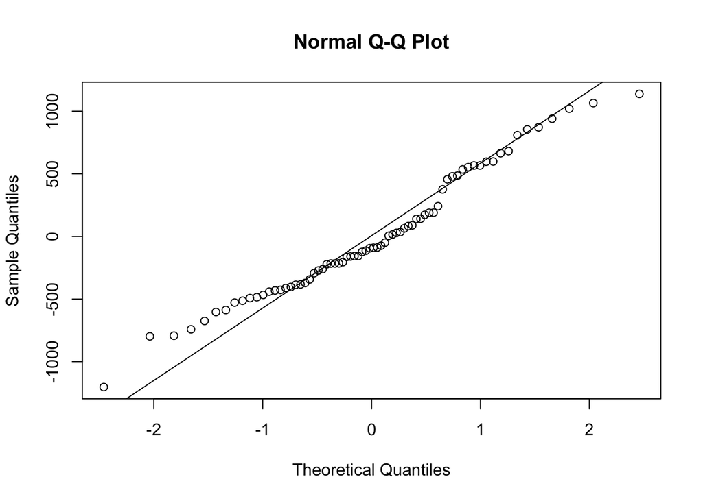

```r
qqnorm(epsilon)
qqline(epsilon)
```

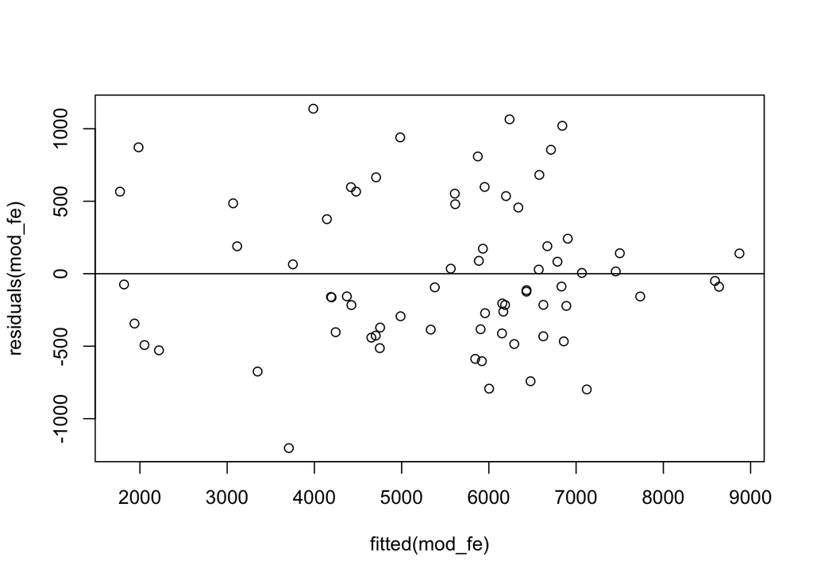

```r
plot(residuals(mod_fe) ~ fitted(mod_fe))
abline(h = 0)
```

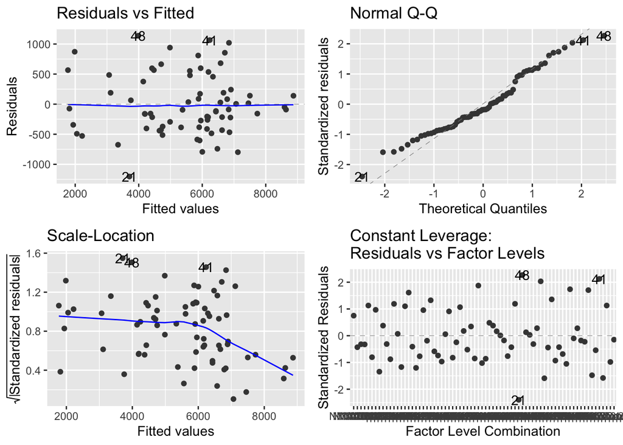

```r
autoplot(mod_fe)
```

```r
shapiro.test(epsilon)
```

```
##
##  Shapiro-Wilk normality test
##
## data:  epsilon
## W = 0.97046, p-value = 0.08819
```

```r
car::ncvTest(mod_fe) #homoscedasticity test for more complex models - AKA Breusch-Pagan test
```

```
## Non-constant Variance Score Test
## Variance formula: ~ fitted.values
## Chisquare = 1.745376, Df = 1, p = 0.18646
```

Results indicate the satisfaction of linear model assumptions, so we can move onto multiple comparisons tests.